# Installing and Managing R Packages

Eren Ada

2025-02-14

[figure not shown]

## Understanding R Packages

R packages are collections of R functions, data, and compiled code that extend the capabilities of base R. They are essential for modern R programming because:

1. **Code Reuse**
   - Access pre-written, tested functions
   - Save time by not reinventing the wheel
   - Benefit from community-developed solutions
2. **Quality Assurance**
   - Packages on CRAN are tested extensively
   - Regular updates and bug fixes
   - Community feedback and improvements
3. **Documentation**
   - Detailed function documentation
   - Usage examples and vignettes
   - Clear dependency information

### The R Package Ecosystem

R has two main types of packages:

1. **Base Packages**:
   - Come pre-installed with R
   - Essential functionality (stats, graphics, utils)
   - Maintained by the R Core Team
2. **Contributed Packages**:
   - Created by the R community
   - Available on CRAN
   - Cover specialized topics and methods

## Installing Packages

There are several ways to install R packages, each with its own use case:

### Using install.packages()

The most common method for installing packages from CRAN:

```r
# Install a single package
# This downloads and installs the latest version from CRAN
install.packages("tidyverse")

# Install multiple packages at once
# Useful when setting up a new project
install.packages(c("ggplot2", "dplyr", "readr"))
```

### Essential Packages for this Workshop

These packages form the foundation of modern data analysis in R:

```r
# Install all essential packages for data science
install.packages(c(
  "tidyverse",  # Meta-package for data science (includes several packages below)
  "ggplot2",    # Grammar of Graphics plotting system
  "dplyr",      # Data manipulation and transformation
  "readr",      # Fast and friendly file reading
  "tidyr",      # Tools for data tidying
  "rmarkdown",  # Dynamic document generation
  "knitr"       # R markdown document processing
))
```

## Loading Packages

After installation, packages must be loaded into your R session:

```r
# Load the entire tidyverse collection
# This includes ggplot2, dplyr, tidyr, readr, and more
library(tidyverse)

# Load specific packages for more control
# This is useful when you want to avoid loading unnecessary packages
library(ggplot2)  # For plotting
library(dplyr)    # For data manipulation
```

### Checking Package Version

Version information is crucial for reproducibility:

```r
# Check installed version of a package
# Important for reproducibility and debugging
packageVersion("tidyverse")
```

```
## [1] '2.0.0'
```

## Managing Packages

### Updating Packages

Regular updates ensure you have the latest features and bug fixes:

```r
# Update all installed packages
# This can take some time if you have many packages
update.packages()

# Update a specific package
# This reinstalls the package with the latest version
install.packages("ggplot2")
```

### Viewing Installed Packages

Monitor your R package environment:

```r
# List all installed packages with their versions
# Useful for documentation and troubleshooting
installed.packages()[, c("Package", "Version")]
```

[output not shown]

[output cut: 432 more lines]

[output not shown]

## Best Practices

1. **Document Dependencies**
   - List required packages at script start
   - Include version numbers
   - Note any special installation requirements
2. **Version Control**
   - Track package versions
   - Document major version changes
   - Test code with new versions
3. **Load Packages Early**
   - Load all packages at script start
   - Group related packages together
   - Comment why each package is needed
4. **Use Specific Functions**
   - Use package::function() notation for clarity
   - Avoid masking conflicts
   - Make dependencies explicit

## Example Usage

Here’s a practical example combining several packages:

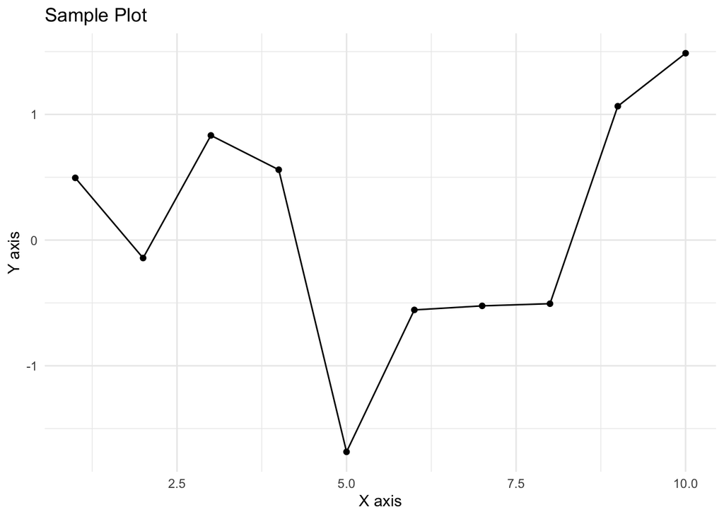

```r
# Load required packages
library(ggplot2)    # For creating plots
library(dplyr)      # For data manipulation

# Create sample data for demonstration
data <- data.frame(
  x = 1:10,                    # Sequence from 1 to 10
  y = rnorm(10)                # 10 random normal values
)

# Use dplyr to transform data
# The pipe operator (%>%) makes the code more readable
data <- data %>%
  mutate(z = y * 2)            # Create new column z

# Create a plot using ggplot2
# This demonstrates the layered approach to plotting
ggplot(data, aes(x = x, y = y)) +
  geom_point() +                # Add points
  geom_line() +                 # Add connecting lines
  theme_minimal() +             # Use minimal theme
  labs(title = "Sample Plot",   # Add labels
       x = "X axis",
       y = "Y axis")
```

## Troubleshooting

Common package-related issues and solutions:

1. **Package not found**
   - Check installation
   - Verify package name
   - Check CRAN availability
2. **Loading conflicts**
   - Use package::function()
   - Load packages in correct order
   - Be aware of masked functions
3. **Dependencies**
   - Install required dependencies
   - Check version compatibility
   - Update dependent packages

```r
# Safe package loading with installation check
if (!require("ggplot2")) {
  install.packages("ggplot2")
}

# Check currently loaded packages
# Useful for debugging namespace conflicts
search()

# Access package documentation
help(package = "ggplot2")
```

## Finding Help and Documentation

R provides extensive documentation systems:

### Package Documentation

```r
# Get package overview
# Shows package description, functions, and datasets
help(package = "dplyr")

# Get function-specific help
# Two equivalent ways to access function documentation
?dplyr::filter
help("filter", package = "dplyr")

# See function examples
# Useful for learning how to use functions
example("filter", package = "dplyr")
```

### Package Vignettes

Vignettes provide detailed tutorials and examples:

```r
# List all available vignettes
# Shows documentation for all installed packages
vignette()

# List vignettes for specific package
# Useful when learning a new package
vignette(package = "dplyr")

# Open main package vignette
# Usually provides the best introduction
vignette("dplyr")

# Open specific vignette
# For detailed information on specific topics
vignette("programming", package = "dplyr")
```

### Online Resources

Additional learning resources:

1. **Package Websites**
   - Documentation: tidyverse.org
   - Tutorials: r-project.org
   - Examples: rdrr.io
2. **GitHub Repositories**
   - Source code
   - Issue tracking
   - Development versions
3. **Cheatsheets**
   - Quick reference
   - Visual guides
   - Common operations

```r
# Open package documentation in browser
# Provides access to all vignettes
browseVignettes("dplyr")

# Check package updates and changes
# Important when updating packages
news(package = "dplyr")
```

## Next Steps

After mastering package management:

1. **Explore More Packages**
   - Browse CRAN Task Views
   - Follow R-bloggers
   - Join R communities
2. **Learn Package Development**
   - Create your own packages
   - Contribute to existing packages
   - Share code with others
3. **Best Practices**
   - Maintain reproducible environments
   - Document dependencies
   - Stay updated with new releases